# Lab 06 — Hypothesis Testing from Claims

EAES 480 — Modern Statistics in Earth & Environmental Science

March 11, 2026

# Overview

This lab introduces **hypothesis testing** as an extension of sampling, bootstrap distributions, and uncertainty quantification.

The core idea is simple:

> A **claim** about the population becomes a **null hypothesis**.

You will use the **US-AMS simplified AmeriFlux dataset** again and test claims about population means using:

- one sample,
- a bootstrap estimate of uncertainty,
- a z-statistic,
- and a p-value.

This lab emphasizes **reasoning from claims to tests**, not just mechanics.

# Learning goals

By the end of this lab, you should be able to:

- Turn a verbal claim into a null hypothesis
- Choose a variable and define the relevant population parameter
- Draw a sample and estimate a mean
- Use bootstrap resampling to estimate uncertainty in that mean
- Compute a z-statistic and p-value
- Interpret a hypothesis test in plain language
- Connect confidence intervals and hypothesis tests

# Data

## Load and inspect

```r
# GOAL: Read the dataset and clean the names.

df <- read_csv("data/us-ams-simple.csv", na = c("-9999")) %>%
  clean_names() %>%
  filter(year_local == 2023)

glimpse(df)
```

```
## Rows: 16,973
## Columns: 10
## $ year_local <dbl> 2023, 2023, 2023, 2023, 2023, 2023, 2023, 2023, 2023, 2023,…
## $ doy        <dbl> 1.0000, 1.0208, 1.0416, 1.0624, 1.0833, 1.1041, 1.1249, 1.1…
## $ daytime    <dbl> 0, 0, 0, 0, 0, 0, 0, 0, NA, NA, 0, 0, 0, 0, 0, 0, 1, 1, 1, …
## $ fc         <dbl> 1.4444700, 1.0018700, 1.7665700, 0.4639850, 0.8243290, 0.64…
## $ le         <dbl> -2.975490, -1.814240, -5.101540, -4.854642, -2.419090, -10.…
## $ ta         <dbl> 7.433350, 7.783740, 8.273390, 8.702240, 8.896600, 8.567610,…
## $ reco       <dbl> 1.291612, 1.312279, 1.341193, 1.366625, 1.378268, 1.359013,…
## $ gpp        <dbl> -0.1528577, 0.3104090, -0.4253767, 0.9026402, 0.5539394, 0.…
## $ swc        <dbl> 36.13111, 36.11948, 36.11560, 36.11172, 36.11172, 36.10008,…
## $ ts         <dbl> 2.50, 2.50, 2.50, 2.50, 2.50, 2.50, 2.50, 2.50, 2.50, 2.50,…
```

## Derive time columns (if needed)

```r
# GOAL: Create date / month / day_night columns as in earlier labs.

df <- df %>%
  mutate(
    date = as.Date(floor(doy) - 1, origin = paste0(year_local, "-01-01")),
    month = month(date, label = TRUE, abbr = TRUE),
    day_night = if_else(daytime == 1, "Day", "Night")
  )
```

# Part I — From claim to hypothesis test

## 1) Choose a variable

Choose **one numeric variable** from the dataset.

Possible examples: - `swc` - `ta` - `fc` - `gpp` - `le`

```r
target_var <- "swc"

# CHECK: does this variable exist?
target_var %in% names(df)
```

```
## [1] TRUE
```

## 2) Describe the population parameter

Write the population parameter you care about:

> $\mu$ = the true 2023 population mean of `swc`

Fill in the blank in words:

> In this lab, my population parameter is the true annual mean of **`soil water content (swc)`** at the US-AMS site.

## 3) Make a claim

Write a claim about the population mean for your variable.

Examples: - “The annual mean soil water content is 0.30.” - “The annual mean air temperature is 10 °C.” - “The annual mean latent heat flux is 40 W m$^{-2}$.”

Now turn your claim into hypotheses:

- Null hypothesis: $H_0: \mu = \mu_0$
- Alternative hypothesis: $H_A: \mu \neq \mu_0$

Fill these in:

> My claim is: `The annual mean soil water content is 36.`

> $H_0$: `The true 2023 mean soil water content is 36.`

> $H_A$: `The true 2023 mean soil water content is not 36.`

## 4) Draw one sample and compute the sample mean

```r
# GOAL: Draw one random sample and compute its mean.

set.seed(111)

n_samp <- 200   # e.g., 200

samp <- df %>%
  filter(!is.na(.data[[target_var]])) %>%
  slice_sample(n = n_samp)

sample_mean <- mean(samp[[target_var]], na.rm = TRUE)

sample_mean
```

```
## [1] 36.05218
```

**Prompt (2–3 sentences):** How does your sample mean compare to your claim? Is it close, or already quite different?

> My sample mean is 36.05, which is extremely close to my claim of 36. Based on this sample alone, the claim appears plausible. At this stage, there is no clear evidence that the sample mean differs meaningfully from the claimed population mean.

## 5) Bootstrap the sample mean

```r
# GOAL: Bootstrap the sample mean to estimate uncertainty.

set.seed(111)

B <- 4000   # e.g., 4000

boot_means <- replicate(
  B,
  mean(sample(samp[[target_var]], size = n_samp, replace = TRUE), na.rm = TRUE)
)

head(boot_means)
```

```
## [1] 35.69694 36.70598 35.94971 35.96849 35.85064 36.48726
```

## 6) Estimate uncertainty

```r
# GOAL: Compute the bootstrap SE and 95% CI.

boot_se <- sd(boot_means)
boot_ci <- quantile(boot_means, probs = c(0.025, 0.975))

tibble(
  sample_mean = sample_mean,
  boot_se = boot_se,
  ci_lower = boot_ci[1],
  ci_upper = boot_ci[2]
)
```

| sample_mean | boot_se | ci_lower | ci_upper |
| --- | --- | --- | --- |
| 36.05218 | 0.5677893 | 34.92003 | 37.1463 |

**Prompt (2–3 sentences):** What does the bootstrap SE tell you? What does the 95% CI tell you?

> The bootstrap standard error (SE) describes how much the sample mean would vary across repeated resamples, so it represents the uncertainty in my estimate. In this case, the SE is about 0.57, suggesting that the estimate is relatively stable. The 95% bootstrap confidence interval provides a plausible range for the true 2023 mean soil water content. Therefore, we are 95% confident that the true 2023 mean soil water content lies between approximately 34.9 and 37.1.

## 7) Convert the claim into a formal test

Define the null value from your claim.

```r
# GOAL: Compute z and p-value for your claim.

mu0 <- 36  # numeric claim value

z_stat <- (sample_mean - mu0) / boot_se

p_value <- 2 * pnorm(-abs(z_stat))

tibble(
  sample_mean = sample_mean,
  mu0 = mu0,
  boot_se = boot_se,
  z_stat = z_stat,
  p_value = p_value
)
```

| sample_mean | mu0 | boot_se | z_stat | p_value |
| --- | --- | --- | --- | --- |
| 36.05218 | 36 | 0.5677893 | 0.09189209 | 0.9267838 |

## 8) Interpret the result

Use your p-value and CI to answer:

- Does the 95% CI include the null value?
- Is the p-value small or large?
- Would you reject the null hypothesis at $\alpha = 0.05$?

Fill in:

> The null value `is` inside my 95% CI.

> My p-value is `0.927`, which is large.

> Therefore, I would not reject $H_0$ at the 0.05 level.

**Prompt (4–6 sentences):** Explain your decision in plain language. Do the data make the claim look plausible or surprising? Be careful: “fail to reject” does not mean “prove true.”

> In plain language, the data make the claim that the annual mean soil water content is 36 appear plausible rather than surprising. The null value of 36 lies within my 95% confidence interval, and the p-value is very large (0.927), indicating little evidence against the null hypothesis. Therefore, I would not reject H_0 at the 0.05 significance level. However, failing to reject the null hypothesis does not prove that the true mean is exactly 36; it only means that the data do not provide evidence against that claim.

## 9) Visualize the hypothesis test

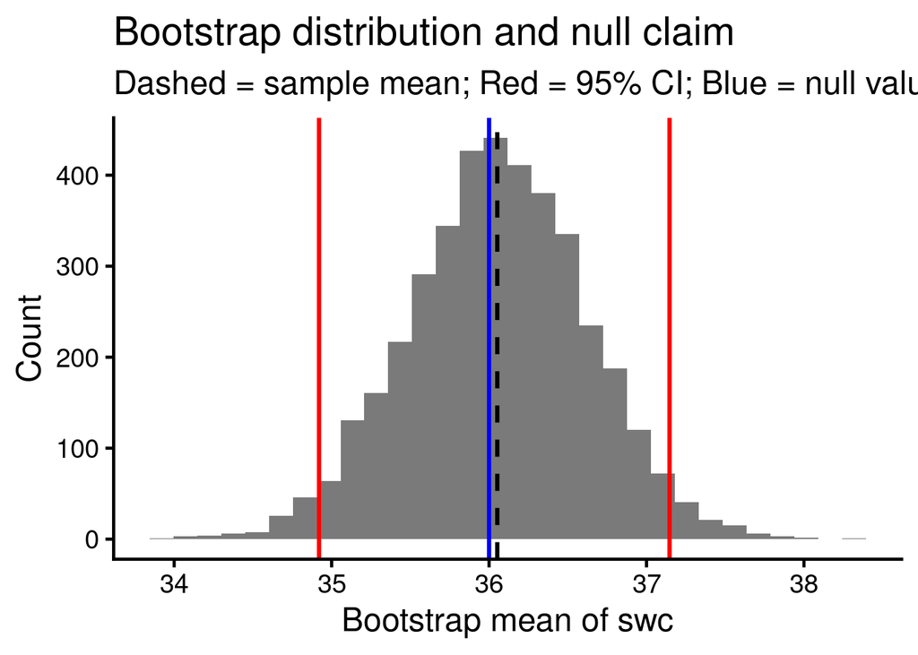

```r
# GOAL: Plot the bootstrap distribution, sample mean, CI, and null value.

ggplot(tibble(boot_mean = boot_means), aes(x = boot_mean)) +
  geom_histogram(bins = 30, alpha = 0.8) +
  geom_vline(xintercept = sample_mean, linetype = "dashed", linewidth = 1.1) +
  geom_vline(xintercept = boot_ci, color = "red", linewidth = 1.1) +
  geom_vline(xintercept = mu0, color = "blue", linewidth = 1.1) +
  theme_classic(base_size = 18) +
  labs(
    x = paste0("Bootstrap mean of ", target_var),
    y = "Count",
    title = "Bootstrap distribution and null claim",
    subtitle = "Dashed = sample mean; Red = 95% CI; Blue = null value"
  )
```

**Prompt (2–3 sentences):** Does the plot agree with your p-value-based conclusion? Explain.

> Yes, the plot is consistent with the conclusion based on the p-value. The null value of 36 lies near the center of the bootstrap distribution and clearly falls within the 95% confidence interval. This visual pattern supports the statistical result that the claim is plausible given the observed data.

## 10) Try a second claim (short extension)

Keep the same variable, but test a **different null value**.

```r
# GOAL: Test a second claim using the same sample and bootstrap SE.

mu0_alt <- 30

z_stat_alt <- (sample_mean - mu0_alt) / boot_se
p_value_alt <- 2 * pnorm(-abs(z_stat_alt))

tibble(
  mu0_alt = mu0_alt,
  z_stat_alt = z_stat_alt,
  p_value_alt = p_value_alt
)
```

| mu0_alt | z_stat_alt | p_value_alt |
| --- | --- | --- |
| 30 | 10.65919 | 1.579647e-26 |

**Prompt (3–4 sentences):** How did changing the null value change the conclusion? What does this tell you about the relationship between the null hypothesis and the observed estimate?

> Changing the null value from 36 to 30 substantially changes the conclusion. When the null value was 36, it was very close to the observed sample mean, so the p-value was large and I did not reject H_0. When the null value was changed to 30, it became much farther from the observed estimate, resulting in a much larger z-statistic and an extremely small p-value. This demonstrates that hypothesis testing depends on how far the claimed value is from the observed estimate relative to the uncertainty in that estimate.

# Part II — Comparing group means with t-tests

In Part I, you tested a claim about **one population mean**.

Now you will extend the same logic to compare **two group means**.

The key idea is:

> A two-sample t-test asks whether the difference between two group means is large relative to the uncertainty in that difference.

You will first work with a built-in grouping variable (**day vs night**), then choose a second grouping variable of your own.

## 11) Create a day/night grouping variable

If you already created `day_night` earlier, you can reuse it. Otherwise, create it here.

```r
# GOAL: create a day/night grouping variable from `daytime`.

df <- df %>%
  mutate(
    day_night = if_else(daytime == 1, "Day", "Night")
  ) %>%
  filter(!is.na(daytime))

df %>% count(day_night)
```

| day_night | n |
| --- | --- |
| Day | 8287 |
| Night | 7767 |

## 12) Choose a response variable for the t-test

Pick one numeric response variable to compare between groups.

Possible examples: - `ta` - `swc` - `fc` - `gpp` - `le`

```r
response_var <- "ta"

# CHECK: does this variable exist?
response_var %in% names(df)
```

```
## [1] TRUE
```

## 13) Visualize the response by day/night

Create a plot that shows how your response variable differs between Day and Night.

You may use: - `geom_boxplot()` - `geom_violin()` - `geom_jitter()` - or a combination

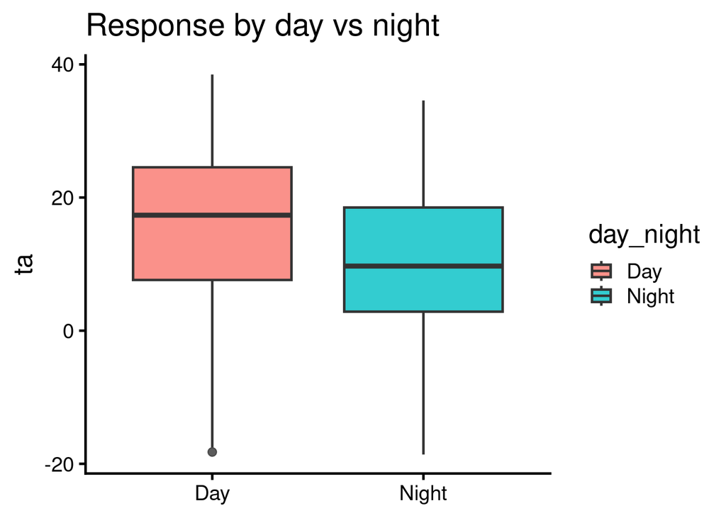

```r
# GOAL: visualize the response by day/night group.

df %>%
  filter(!is.na(.data[[response_var]])) %>%
  ggplot(aes(x = day_night, y = .data[[response_var]], fill = day_night)) +
  geom_boxplot(alpha = 0.8) +
  theme_classic(base_size = 18) +
  labs(
    x = NULL,
    y = response_var,
    title = "Response by day vs night"
  )
```

**Prompt (2–3 sentences):** Before running the test, what do you predict?  
Do the groups look different in center? In spread?

> Before running the test, I would expect air temperature to be higher during the day than at night. The boxplot shows that the Day group has a noticeably higher center (about 16°C) compared to the Night group (about 10°C). The spread of the two groups appears somewhat similar, suggesting that the primary difference is in the average temperature rather than variability.

## 14) Summarize the two groups

Compute the group means, SDs, and sample sizes.

```r
# GOAL: summarize the response variable by day/night group.

group_summary <- df %>%
  filter(!is.na(.data[[response_var]])) %>%
  group_by(day_night) %>%
  summarise(
    mean_response = mean(.data[[response_var]], na.rm = TRUE),
    sd_response = sd(.data[[response_var]], na.rm = TRUE),
    n = n(),
    .groups = "drop"
  )

group_summary
```

| day_night | mean_response | sd_response | n |
| --- | --- | --- | --- |
| Day | 16.02227 | 10.352428 | 8287 |
| Night | 10.14325 | 9.379496 | 7767 |

## 15) State the hypotheses for the day/night comparison

Write hypotheses in words and symbols.

Use this structure:

- Null: the two group means are equal
- Alternative: the two group means are different

Fill in:

> My response variable is `air temperature (ta)`

> $H_0$: `The mean air temperature is the same during Day and Night.`

> $H_A$: `The mean air temperature differs between Day and Night.`

## 16) Run a two-sample t-test

Use `t.test()` to compare the means of your response variable between Day and Night.

```r
# GOAL: run a two-sample t-test by formula.

t.test(
  reformulate("day_night", response_var),
  data = df
)
```

```
##
##  Welch Two Sample t-test
##
## data:  ta by day_night
## t = 37.745, df = 16034, p-value < 2.2e-16
## alternative hypothesis: true difference in means between group Day and group Night is not equal to 0
## 95 percent confidence interval:
##  5.573716 6.184308
## sample estimates:
##   mean in group Day mean in group Night
##            16.02227            10.14325
```

**Prompt (4–6 sentences):** Report the p-value and confidence interval.  
Would you reject the null hypothesis at $\alpha = 0.05$?  
What does the result imply about day vs night differences in your chosen variable?

> The p-value is less than 2.2e-16, which is extremely small. The 95% confidence interval for the difference in means is approximately 5.57 to 6.18°C. Because the p-value is far below 0.05, I would reject the null hypothesis. This result indicates that mean air temperature differs significantly between Day and Night. Specifically, daytime air temperature is on average about 5.9°C higher than nighttime air temperature.

## 17) Connect the t-test to a confidence interval

Extract the confidence interval and interpret it as a difference in means.

```r
# GOAL: store the t-test result in an object.

tt_daynight <- t.test(
  reformulate("day_night", response_var),
  data = df
)

tt_daynight$conf.int
```

```
## [1] 5.573716 6.184308
## attr(,"conf.level")
## [1] 0.95
```

**Prompt (2–3 sentences):** Does the confidence interval include 0?  
How does that connect to the hypothesis test decision?

> No, the confidence interval does not include 0. The interval ranges from approximately 5.57 to 6.18, indicating that the difference in mean temperature between Day and Night is clearly positive. This is consistent with the t-test result and supports rejecting the null hypothesis.

## 18) Bootstrap view of the same comparison (conceptual extension)

Create bootstrap distributions of the **group means** for Day and Night separately.

```r
set.seed(111)

B <- 2000   # e.g., 2000

x_day <- df %>%
  filter(day_night == "Day") %>%
  pull(.data[[response_var]]) %>%
  na.omit()

x_night <- df %>%
  filter(day_night == "Night") %>%
  pull(.data[[response_var]]) %>%
  na.omit()

boot_day <- replicate(
  B,
  mean(sample(x_day, size = length(x_day), replace = TRUE))
)

boot_night <- replicate(
  B,
  mean(sample(x_night, size = length(x_night), replace = TRUE))
)

boot_groups <- bind_rows(
  tibble(group = "Day", mean_est = boot_day),
  tibble(group = "Night", mean_est = boot_night)
)
```

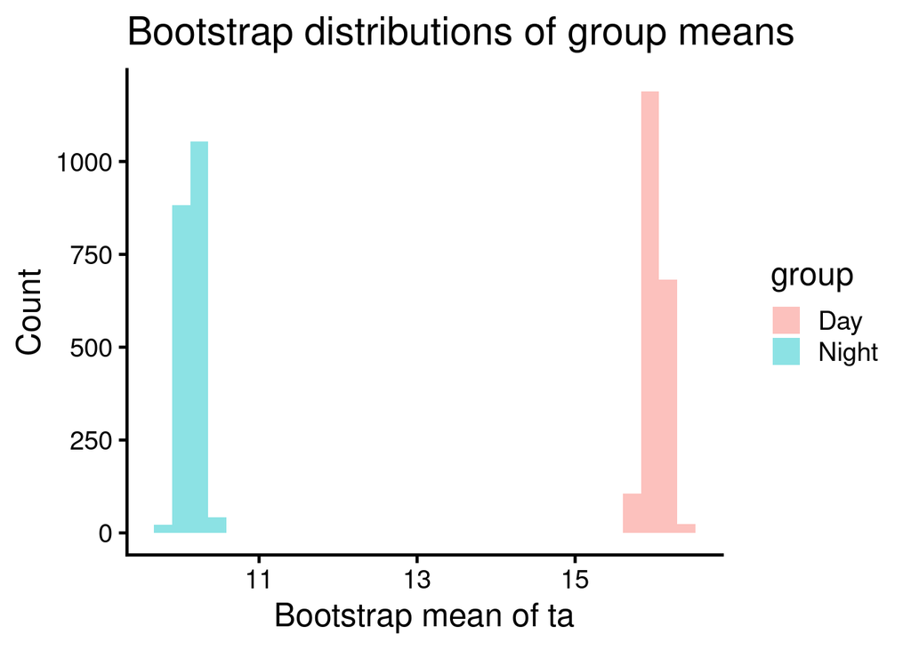

```r
# GOAL: visualize the bootstrap distributions by group.

ggplot(boot_groups, aes(x = mean_est, fill = group)) +
  geom_histogram(alpha = 0.45, bins = 30, position = "identity") +
  theme_classic(base_size = 18) +
  labs(
    x = paste0("Bootstrap mean of ", response_var),
    y = "Count",
    title = "Bootstrap distributions of group means"
  )
```

**Prompt (3–4 sentences):** How does this bootstrap visualization help you understand the t-test result?  
Do the plausible group means strongly overlap, or are they clearly separated?

> The bootstrap distributions show that the Day and Night mean temperatures are clearly separated, with very little overlap between the two distributions. This indicates that the difference between the group means is large relative to the uncertainty in the estimates. The visualization therefore supports the t-test result that air temperature differs significantly between Day and Night.

## 19) Choose a second grouping variable of your own

Now define **one additional grouping variable** and repeat the t-test workflow.

Possible ideas: - month grouped into two seasons (e.g., winter vs summer) - a high/low split of another continuous variable - a wet/dry split of SWC - a daytime subset grouped by month category

You must: - define the grouping variable clearly - explain why the grouping is scientifically meaningful

```r
# GOAL: create your own two-level grouping variable.

df <- df %>%
  mutate(
    my_group = if_else(month %in% c("May", "Jun", "Jul", "Aug", "Sep"),
                       "Warm",
                       "Cool")
  )

df %>% count(my_group)
```

| my_group | n |
| --- | --- |
| Cool | 9446 |
| Warm | 6608 |

**Prompt (2–3 sentences):** Why did you choose this grouping variable? What scientific contrast are you testing?

> I chose a warm-season versus cool-season grouping because seasonal temperature patterns are an important aspect of environmental data. This grouping allows me to test whether mean air temperature differs between the warmer and cooler parts of the year.

## 20) Visualize and test your second grouping variable

Repeat the workflow: 1. visualize 2. summarize 3. state hypotheses 4. run `t.test()` 5. interpret

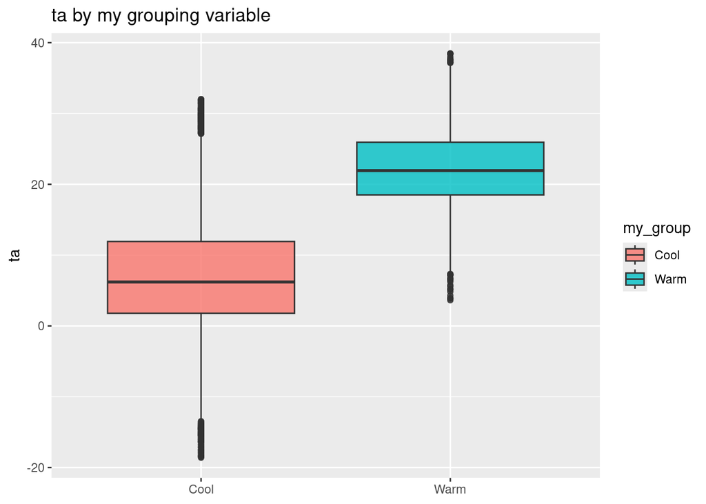

```r
# GOAL: visualize your response by your chosen grouping variable.

df %>%
  filter(!is.na(.data[[response_var]])) %>%
  ggplot(aes(x = my_group, y = .data[[response_var]], fill = my_group)) +
  geom_boxplot(alpha = 0.8)  +
  labs(
    x = NULL,
    y = response_var,
    title = paste0(response_var, " by my grouping variable")
  )
```

```r
# GOAL: summarize your response variable by your chosen grouping variable.

my_group_summary <- df %>%
  filter(!is.na(.data[[response_var]])) %>%
  group_by(my_group) %>%
  summarise(
    mean_response = mean(.data[[response_var]], na.rm = TRUE),
    sd_response = sd(.data[[response_var]], na.rm = TRUE),
    n = n(),
    .groups = "drop"
  )
my_group_summary
```

| my_group | mean_response | sd_response | n |
| --- | --- | --- | --- |
| Cool | 6.94500 | 8.060839 | 9446 |
| Warm | 22.08788 | 5.564110 | 6608 |

```r
# GOAL: run a two-sample t-test for your chosen grouping variable.

tt_second <- t.test(
  reformulate("my_group", response_var),
  data = df
)

tt_second
```

```
##
##  Welch Two Sample t-test
##
## data:  ta by my_group
## t = -140.82, df = 16049, p-value < 2.2e-16
## alternative hypothesis: true difference in means between group Cool and group Warm is not equal to 0
## 95 percent confidence interval:
##  -15.35366 -14.93210
## sample estimates:
## mean in group Cool mean in group Warm
##            6.94500           22.08788
```

**Prompt (5–6 sentences):** Compare the day/night t-test to your second grouping-variable test.  
Which contrast was stronger? Which was more scientifically meaningful?  
Did the two tests produce similar or different conclusions?

> The second t-test compares air temperature between the Warm and Cool seasons. The mean temperature in the Cool group is about 6.94°C, while the mean temperature in the Warm group is about 22.1°C. This represents a very large difference of roughly 15°C on average. The p-value is extremely small (p < 2.2e-16), so I would reject the null hypothesis that the two group means are equal. Compared with the day–night comparison, this seasonal contrast is even stronger because the difference in means is much larger. Both tests show statistically significant differences, but the warm versus cool seasonal contrast is more meaningful for understanding broader seasonal climate patterns.

## 21) Final reflection

Answer in **4–6 sentences**:

- How is a two-sample t-test similar to the one-mean hypothesis test from Part I?
- What changes when we move from “testing one mean” to “testing a difference in means”?
- How did the bootstrap group-mean plot help your understanding?

> A two-sample t-test is similar to the one-mean hypothesis test in Part I because both methods compare an observed estimate to a reference value relative to its uncertainty. In Part I, we tested whether a single population mean differed from a claimed value. In Part II, we instead tested whether the difference between two group means was significantly different from zero. The main difference is that the parameter of interest becomes the difference between two means rather than a single mean. The bootstrap group-mean plots helped illustrate this concept by showing the plausible ranges of the two group means. When the bootstrap distributions were clearly separated, it became easier to understand why the t-test produced such a small p-value.

# Submission

- Knit your `.Rmd` to HTML.
- Commit and push both the `.Rmd` and knitted `.html` to your GitHub repo.
- Submit the GitHub repository link on Canvas.